# In Class DT

Adriel Kim

December 7, 2017

```r
library(rio)
library(plyr)
library(tidyverse)
library(rpart)
library(psych)
library(pROC)
```

```r
#install.packages("rpart.plot")
library(rpart.plot)
#install.packages("rattle")
library(rattle)
library(caret)
library(C50) #Need this to pass into caret
library(mlbench)
library(MLmetrics)
library(RColorBrewer)
library(ROCR)

library(mltools)
library(data.table)
```

## Problem Description

Congrats! You just graduated UVA’s MSDS program and got a job working at the Treasury Department. In partnership with Congress members the Treasury has been ask to come up with innovative ways to create tax policy. In doing so they want to be able to reliably predict whether American workers make more than $50,000 a year and also which variables seem to be most contributing to predicting this outcome.

You would like to be able to explain the model to the mere mortals around you but need a fairly robust and flexible approach so you’ve chosen to use decision trees to get started and will possibly move to a ensemble model if needed.

In doing so, similar to great data scientists of the past you remembered the excellent education provided to you at UVA in a undergrad data science course and have outline 20ish steps that will need to be undertaken to complete this task (you can add more or combine if needed). As always, you will need to make sure to #comment your work heavily.

## Loading Data

```r
#loading data and adding appropriate header labels.
url <- "http://archive.ics.uci.edu/ml/machine-learning-databases/adult/adult.data"
names <- c("age","workclass","fnlwgt","education","education-num","marital-status","occupation","relationship","race","sex","capital-gain","capital-loss","hours-per-week","native-country", "salary")
xx <- readr::read_csv(url)
names(xx) <- names
xx <- na.omit(xx)#omit any rows with NA values
selection =c('workclass' ,'education', 'marital-status', 'occupation', 'relationship', 'race', 'sex', 'native-country', 'salary')
factors =c('workclass' ,'education', 'marital-status', 'occupation', 'relationship', 'race', 'sex', 'native-country')
xx <- xx[,selection]
#xx$salary <- as.factor(xx$salary)#convert to factor, essentially a categorical variable
#xx$`native-country` <- as.factor(xx$`native-country`)
xx[,factors] <- lapply(xx[,factors], as.factor)
xx1h <- one_hot(as.data.table(xx),cols = "auto",sparsifyNAs = TRUE,naCols = TRUE,dropCols = TRUE,dropUnusedLevels = TRUE)
xx1h$salary = as.factor(xx1h$salary)
levels(xx$salary) <- c("less", "greater")
levels(xx1h$salary) <- c("less", "greater")

View(xx)
View(xx1h)
```

Footnotes: - You can add or combine steps if needed - Also, remember to try several methods during evaluation and always be mindful of how the model will be used in practice. - Make sure all your variables are the correct type (factor, character, etc.)

```r
#3 Don't check for correlated variables....because it doesn't matter with
# Decision Trees...the make local greedy decisions.
```

```r
#4 Guess what, you also don't need to standardize the data,
#because DTs don't give a ish, they make local decisions...keeps getting easier
```

```r
#5 Determine the baserate or prevalence for the classifier,
# what does this number mean?

#Prevalence is the proportion of postive examples in the dataset
(prevalence <- table(xx$salary)[[2]]/length(xx$salary))
```

```
## [1] 0.240817
```

## Splitting data

```r
#6 Split your data into test, tune, and train. (70/15/15)
part_index_1 <- caret::createDataPartition(xx1h$salary,
                                           times=1,
                                           p = 0.70,
                                           groups=1,
                                           list=FALSE)

train <- xx1h[part_index_1, ]
tune_and_test <- xx1h[-part_index_1, ]

#The we need to use the function again to create the tuning set

tune_and_test_index <- createDataPartition(tune_and_test$salary,
                                           p = .5,
                                           list = FALSE,
                                           times = 1)

tune <- tune_and_test[tune_and_test_index, ]#aka, validation set
test <- tune_and_test[-tune_and_test_index, ]#final testing set


dim(train)
```

```
## [1] 22793   103
```

```r
dim(test)# these will be slightly off because the data set isn't perfectly even
```

```
## [1] 4883  103
```

```r
#buts its not a issue.
dim(tune)
```

```
## [1] 4884  103
```

```r
#View(train)
View(train)
View(tune)
```

## Impotant Variables

```r
# Choose the features and classes
#8 View the results, what is the most important variable for the tree?

features <- train[,-c("salary")]#dropping 12 and 13. 12 essentially predicts 13
View(features)
View(train[,c("salary")])
#View(features)
#perfectly and 13 is our target variable
#View(features)
train$salary = as.factor(train$salary)
levels(train$salary) <- c("less", "greater")

target <- train$salary

View(target)

str(features)
```

```
## Classes 'data.table' and 'data.frame':   22793 obs. of  102 variables:
##  $ workclass_?                              : int  0 0 0 0 0 0 0 0 0 0 ...
##  $ workclass_Federal-gov                    : int  0 0 0 0 0 0 0 0 0 0 ...
##  $ workclass_Local-gov                      : int  0 0 0 0 0 0 0 0 0 0 ...
##  $ workclass_Never-worked                   : int  0 0 0 0 0 0 0 0 0 0 ...
##  $ workclass_Private                        : int  1 1 1 1 1 1 0 1 1 1 ...
##  $ workclass_Self-emp-inc                   : int  0 0 0 0 0 0 0 0 0 0 ...
##  $ workclass_Self-emp-not-inc               : int  0 0 0 0 0 0 0 0 0 0 ...
##  $ workclass_State-gov                      : int  0 0 0 0 0 0 1 0 0 0 ...
##  $ workclass_Without-pay                    : int  0 0 0 0 0 0 0 0 0 0 ...
##  $ education_10th                           : int  0 0 0 0 0 0 0 0 0 0 ...
##  $ education_11th                           : int  1 0 0 0 0 0 0 0 0 0 ...
##  $ education_12th                           : int  0 0 0 0 0 0 0 0 0 0 ...
##  $ education_1st-4th                        : int  0 0 0 0 0 0 0 0 0 0 ...
##  $ education_5th-6th                        : int  0 0 0 0 0 0 0 0 0 0 ...
```

[output cut: 87 more lines]

```r
str(target)
```

```
##  Factor w/ 2 levels "less","greater": 1 1 1 2 2 2 2 1 2 1 ...
```

```r
#Cross validation process

fitControl <- trainControl(method = "repeatedcv",
                          number = 5,
                          repeats = 1,
                          returnResamp="all",
                          classProbs = TRUE,
                          allowParallel = TRUE)

# number - number of folds
# repeats - number of times the CV is repeated, here it's 5 take the average of
# those 5 repeats

# Grid search options for each of the models available in CARET
# http://topepo.github.io/caret/train-models-by-tag.html#tree-based-model

grid <- expand.grid(.winnow = c(TRUE,FALSE),
                    .trials=c(1,5,10,15,20),
                    .model="tree")

#expand.grid - series of options that are available for model training

#winnow - whether to reduce the feature space -  Works to remove unimportant
#features but it doesn't always work, in the above we are winnowing.

#Actually a pretty good StackExchange post on winnowing:
#https://stats.stackexchange.com/questions/83913/understanding-the-output-of-c5-0-classification-model-using-the-caret-package

#trails - number of boosting iterations to try, 1 indicates a single model
#model - type of ml model

View(features)
str(features)
```

```
## Classes 'data.table' and 'data.frame':   22793 obs. of  102 variables:
##  $ workclass_?                              : int  0 0 0 0 0 0 0 0 0 0 ...
##  $ workclass_Federal-gov                    : int  0 0 0 0 0 0 0 0 0 0 ...
##  $ workclass_Local-gov                      : int  0 0 0 0 0 0 0 0 0 0 ...
##  $ workclass_Never-worked                   : int  0 0 0 0 0 0 0 0 0 0 ...
##  $ workclass_Private                        : int  1 1 1 1 1 1 0 1 1 1 ...
##  $ workclass_Self-emp-inc                   : int  0 0 0 0 0 0 0 0 0 0 ...
##  $ workclass_Self-emp-not-inc               : int  0 0 0 0 0 0 0 0 0 0 ...
##  $ workclass_State-gov                      : int  0 0 0 0 0 0 1 0 0 0 ...
##  $ workclass_Without-pay                    : int  0 0 0 0 0 0 0 0 0 0 ...
##  $ education_10th                           : int  0 0 0 0 0 0 0 0 0 0 ...
##  $ education_11th                           : int  1 0 0 0 0 0 0 0 0 0 ...
##  $ education_12th                           : int  0 0 0 0 0 0 0 0 0 0 ...
##  $ education_1st-4th                        : int  0 0 0 0 0 0 0 0 0 0 ...
##  $ education_5th-6th                        : int  0 0 0 0 0 0 0 0 0 0 ...
```

[output cut: 87 more lines]

```r
str(target)
```

```
##  Factor w/ 2 levels "less","greater": 1 1 1 2 2 2 2 1 2 1 ...
```

```r
set.seed(1984)
salary_mdl <- train(x=features,
                y=target,
                method="C5.0",
                tuneGrid=grid,
                trControl=fitControl,
                verbose=TRUE)
salary_mdl #provides us the hyper-parameters that were selected through the grid
```

```
## C5.0
##
## 22793 samples
##   102 predictor
##     2 classes: 'less', 'greater'
##
## No pre-processing
## Resampling: Cross-Validated (5 fold, repeated 1 times)
## Summary of sample sizes: 18234, 18235, 18235, 18234, 18234
## Resampling results across tuning parameters:
##
##   winnow  trials  Accuracy   Kappa
##   FALSE    1      0.8268326  0.4902399
##   FALSE    5      0.8240686  0.4935500
##   FALSE   10      0.8296844  0.4892675
##   FALSE   15      0.8294212  0.4980986
##   FALSE   20      0.8305618  0.4953761
##    TRUE    1      0.8271396  0.4839209
##    TRUE    5      0.8254724  0.4822057
##    TRUE   10      0.8273153  0.4679007
##    TRUE   15      0.8267448  0.4756640
##    TRUE   20      0.8261747  0.4694033
##
## Tuning parameter 'model' was held constant at a value of tree
## Accuracy was used to select the optimal model using the largest value.
## The final values used for the model were trials = 20, model = tree and winnow
##  = FALSE.
```

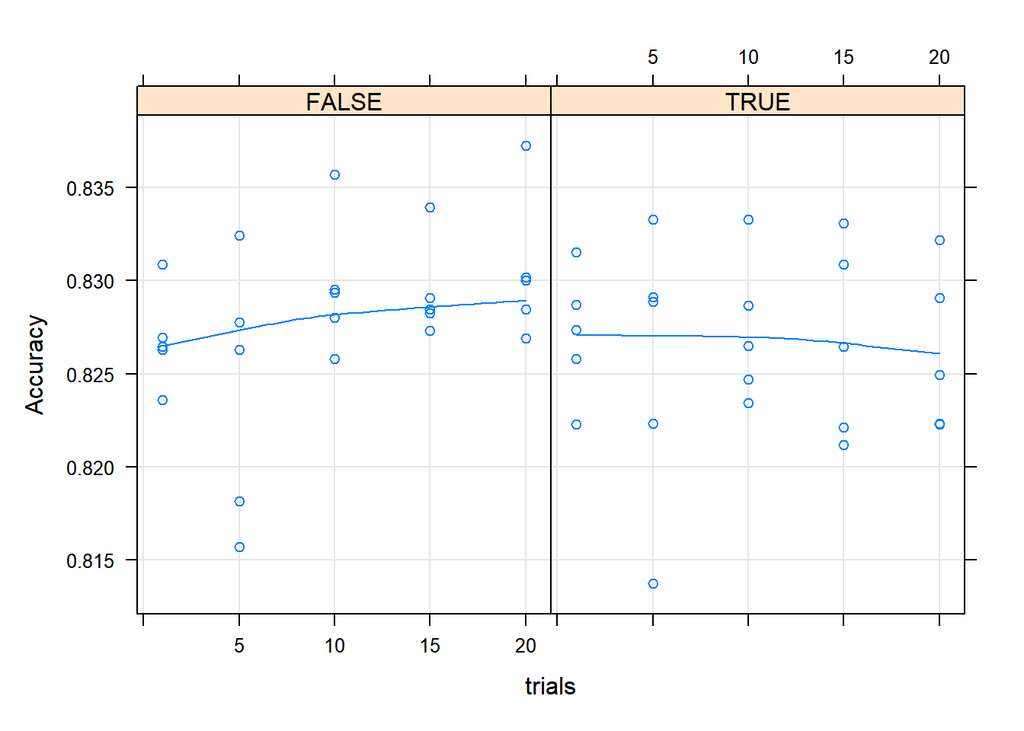

```r
# search process.

#View(salary_mdl$pred)

# visualize the re-sample distributions
xyplot(salary_mdl,type = c("g", "p", "smooth"))
```

```r
varImp(salary_mdl)
```

```
## C5.0 variable importance
##
##   only 20 most important variables shown (out of 102)
##
##                                   Overall
## relationship_Unmarried             100.00
## education_HS-grad                  100.00
## marital-status_Married-civ-spouse  100.00
## occupation_Other-service           100.00
## education_Doctorate                100.00
## relationship_Own-child             100.00
## education_Prof-school               99.97
## education_10th                      99.60
## relationship_Other-relative         96.82
## education_5th-6th                   95.51
## marital-status_Never-married        95.28
## education_11th                      86.14
## education_1st-4th                   84.86
## occupation_Priv-house-serv          84.78
## marital-status_Separated            84.38
## native-country_Vietnam              84.38
## native-country_Dominican-Republic   84.34
## occupation_Handlers-cleaners        84.21
## education_7th-8th                   83.92
## education_Masters                   83.06
```

## Decision Tree Visualization

```r
#View(xx)

#9 Plot the output of the model to see the tree visually
# In order for this decision tree algorithm to run,
# all the variables will need to be turned into factors.
#Make sure your variables are classified correctly.


tree_example = xx #lapply(xx, function(x) as.factor(x))

#This is a handy reference on apply(), lapply(), sapply() are
#all essentially designed to avoid for loops, especially in combination
#with (function (x))

#https://www.r-bloggers.com/using-apply-sapply-lapply-in-r/

str(tree_example)
```

```
## tibble [32,560 x 9] (S3: tbl_df/tbl/data.frame)
##  $ workclass     : Factor w/ 9 levels "?","Federal-gov",..: 7 5 5 5 5 5 7 5 5 5 ...
##  $ education     : Factor w/ 16 levels "10th","11th",..: 10 12 2 10 13 7 12 13 10 16 ...
##  $ marital-status: Factor w/ 7 levels "Divorced","Married-AF-spouse",..: 3 1 3 3 3 4 3 5 3 3 ...
##  $ occupation    : Factor w/ 15 levels "?","Adm-clerical",..: 5 7 7 11 5 9 5 11 5 5 ...
##  $ relationship  : Factor w/ 6 levels "Husband","Not-in-family",..: 1 2 1 6 6 2 1 2 1 1 ...
##  $ race          : Factor w/ 5 levels "Amer-Indian-Eskimo",..: 5 5 3 3 5 3 5 5 5 3 ...
##  $ sex           : Factor w/ 2 levels "Female","Male": 2 2 2 1 1 1 2 1 2 2 ...
##  $ native-country: Factor w/ 42 levels "?","Cambodia",..: 40 40 40 6 40 24 40 40 40 40 ...
##  $ salary        : chr [1:32560] "<=50K" "<=50K" "<=50K" "<=50K" ...
##   ..- attr(*, "levels")= chr [1:2] "less" "greater"
```

```r
tree_example <- as_tibble(tree_example)

table(tree_example$salary)
```

```
##
## <=50K  >50K
## 24719  7841
```

```r
#Also want to add data labels to the target
tree_example$salary <- factor(tree_example$salary,labels = c("0", "1"))

#Build the model
# Train the tree with the rpart() function.
# We'll need to set the seed to make the results reproducible.
set.seed(1980)
tree_example_tree_gini = rpart(salary~.,  #<- formula, response variable ~ predictors
                           #   "." means "use all other variables in data"
                            method = "class",#<- specify method, use "class" for tree
                            parms = list(split = "gini"),#<- method for choosing tree split
                            data = tree_example,#<- data used
                            control = rpart.control(cp=.001))

#Look at the results
tree_example_tree_gini
```

```
## n= 32560
##
## node), split, n, loss, yval, (yprob)
##       * denotes terminal node
##
##   1) root 32560 7841 0 (0.75918305 0.24081695)
##     2) relationship=Not-in-family,Other-relative,Own-child,Unmarried 17799 1178 0 (0.93381651 0.06618349)
##       4) education=10th,11th,12th,1st-4th,5th-6th,7th-8th,9th,Assoc-acdm,Assoc-voc,HS-grad,Preschool,Some-college 14165  476 0 (0.96639605 0.03360395) *
##       5) education=Bachelors,Doctorate,Masters,Prof-school 3634  702 0 (0.80682444 0.19317556)
##        10) education=Bachelors,Masters 3341  558 0 (0.83298414 0.16701586) *
##        11) education=Doctorate,Prof-school 293  144 0 (0.50853242 0.49146758)
##          22) workclass=?,Local-gov,Private,State-gov 217   92 0 (0.57603687 0.42396313)
##            44) occupation=?,Adm-clerical,Farming-fishing,Other-service,Prof-specialty,Tech-support 190   72 0 (0.62105263 0.37894737) *
##            45) occupation=Craft-repair,Exec-managerial,Machine-op-inspct,Sales 27    7 1 (0.25925926 0.74074074) *
##          23) workclass=Federal-gov,Self-emp-inc,Self-emp-not-inc 76   24 1 (0.31578947 0.68421053) *
##     3) relationship=Husband,Wife 14761 6663 0 (0.54860782 0.45139218)
##       6) education=10th,11th,12th,1st-4th,5th-6th,7th-8th,9th,Assoc-acdm,Assoc-voc,HS-grad,Preschool,Some-college 10329 3456 0 (0.66540807 0.33459193)
##        12) occupation=?,Armed-Forces,Craft-repair,Farming-fishing,Handlers-cleaners,Machine-op-inspct,Other-service,Priv-house-serv,Transport-moving 6293 1556 0 (0.75274114 0.24725886) *
##        13) occupation=Adm-clerical,Exec-managerial,Prof-specialty,Protective-serv,Sales,Tech-support 4036 1900 0 (0.52923687 0.47076313)
##          26) education=10th,11th,12th,1st-4th,5th-6th,7th-8th,9th,HS-grad,Preschool 1850  735 0 (0.60270270 0.39729730)
##            52) education=10th,11th,12th,1st-4th,7th-8th,9th,Preschool 227   47 0 (0.79295154 0.20704846) *
##            53) education=5th-6th,HS-grad 1623  688 0 (0.57609365 0.42390635)
##             106) workclass=Local-gov,Private,Self-emp-not-inc,State-gov,Without-pay 1396  548 0 (0.60744986 0.39255014) *
##             107) workclass=Federal-gov,Self-emp-inc 227   87 1 (0.38325991 0.61674009) *
##          27) education=Assoc-acdm,Assoc-voc,Some-college 2186 1021 1 (0.46706313 0.53293687)
##            54) workclass=Local-gov,Private,Self-emp-not-inc,State-gov,Without-pay 1886  924 1 (0.48992577 0.51007423)
##             108) occupation=Adm-clerical,Sales 752  330 0 (0.56117021 0.43882979) *
##             109) occupation=Exec-managerial,Prof-specialty,Protective-serv,Tech-support 1134  502 1 (0.44268078 0.55731922)
##               218) workclass=Self-emp-not-inc,State-gov 178   68 0 (0.61797753 0.38202247) *
##               219) workclass=Local-gov,Private 956  392 1 (0.41004184 0.58995816) *
##            55) workclass=Federal-gov,Self-emp-inc 300   97 1 (0.32333333 0.67666667) *
##       7) education=Bachelors,Doctorate,Masters,Prof-school 4432 1225 1 (0.27639892 0.72360108)
##        14) occupation=?,Adm-clerical,Craft-repair,Farming-fishing,Handlers-cleaners,Machine-op-inspct,Other-service,Transport-moving 756  377 0 (0.50132275 0.49867725)
##          28) native-country=Canada,China,Ecuador,El-Salvador,India,Mexico,Nicaragua,Puerto-Rico,Thailand,Vietnam 34    4 0 (0.88235294 0.11764706) *
##          29) native-country=?,Cambodia,Cuba,England,Germany,Haiti,Iran,Italy,Japan,Laos,Philippines,Poland,South,Taiwan,United-States,Yugoslavia 722  349 1 (0.48337950 0.51662050)
##            58) workclass=Self-emp-not-inc 88   28 0 (0.68181818 0.31818182) *
##            59) workclass=?,Federal-gov,Local-gov,Private,Self-emp-inc,State-gov 634  289 1 (0.45583596 0.54416404)
##             118) occupation=?,Handlers-cleaners,Machine-op-inspct,Other-service,Transport-moving 296  137 0 (0.53716216 0.46283784) *
##             119) occupation=Adm-clerical,Craft-repair,Farming-fishing 338  130 1 (0.38461538 0.61538462) *
##        15) occupation=Armed-Forces,Exec-managerial,Prof-specialty,Protective-serv,Sales,Tech-support 3676  846 1 (0.23014146 0.76985854) *
```

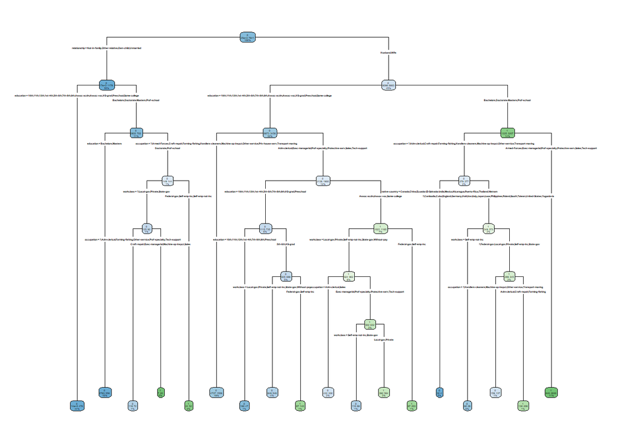

```r
View(tree_example_tree_gini$frame)

# dev - the deviance or the total sum of squares within the node, so if
#       you divide this by the sample size in each node you get the variance
# yval - average value of the trait at the node (for categorical values identifies the group)
# complexity - the value of the parameter used to make the split (gini or information gain)
# ncompete - number of competing variables that can be considered for this split
# nsurrogate - number of surrogate trees (used when there is missing data in the test data set, to mimic the effects of splits in the training data set)
# yval2 - average value of the trait at the node (for categorical values identifies the group), although it can mean different things when the rpart function is used for regression trees or other analyses


rpart.plot(tree_example_tree_gini, type =4, extra = 101)#package rpart.plot
```